**BANA 6043 - Statistical Computing**  
Group 14 - Kishore Kumar T, Eric Greene, Anil Sharma, Deekshith Narayana

# S&P500 Stocks Data Analysis

## 1 . Introduction

### Dataset Overview

The data is from public data recourse: https://www.kaggle.com/paytonfisher/s-p-500-analysis-using-r

The dataset has 505 observations and 14 variables, and it provides the details of all 505 stocks across the row. On a basic level it provides details like high and low of stock prices, market capitaliztion and earnings per share of all stocks. The variables of the dataset are described below:

- Symbol - It is an arrangement of characters—usually letters—representing stocks. Generally they are called ticker
- Name - The Full name of the stock
- Sector - The sector under which the stock is listed.
- Price - The price of the stock. It is the current price of the stock.
- Price/Earnings - It is the ratio of share price to its earnings per share.
- Dividend Yield - It refers to the rate of return earned by the shareholders on their investment.
- Earnings/Share - It indicates the profitability of a company. It is calculated by dividing the company’s net income with its total number of outstanding shares.
- 52 Week Low - Lowest price of stock in a period of 52 weeks(One financial year)
- 52 Week High - Highest price of stock in a period of 52 weeks(One financial year)
- Market Cap - Total worth of the company as determined by the stock market.(the number of outstanding shares multiplied by the share price)
- EBITDA - Earnings before interest, taxes, depreciation, and amortization.
- Price/Sales - It is the ratio of market capitalization to the company's total sales or revenue over the past 12 months. The lower the P/S ratio, the more attractive the investment.
- Price/Book - It is calculated by dividing the company's stock price per share by its book value per share. The P/B ratio reflects the value that market participants attach to a company's equity relative to the book value of its equity.
- SEC Filings - Link to find SEC filings of a particular stock

**OBJECTIVE** : We are trying to determine the influence of predictors on the Earnings/Share of the stock.

## 2 . Importing Libraries Packages and Dataset

```r
install.packages("ggplot2")
install.packages("gridExtra")
install.packages("caret")
install.packages("pls")
install.packages("plsr")
install.packages("treemap")

library(data.table)
library(ggplot2)
library(sqldf)
library(tidyverse)
library(dplyr)
library(GGally)
library(gridExtra)
library(tidyverse)
library(ggplot2)
library(GGally)
library(caret)
library(corrgram)
library(pls)
library(plsr)
library(treemap)
```

```r
# Loading Data
stocks <- read.csv(
  file = "C:/Users/kisho/Downloads/financials.csv",
  header = TRUE,
  stringsAsFactors = TRUE
)
```

## 3. Data Cleaning and Rearranging

```r
## Check the names of the column variables
colnames(stocks)
```

1. 'Symbol'

2. 'Name'

3. 'Sector'

4. 'Price'

5. 'Price.Earnings'

6. 'Dividend.Yield'

7. 'Earnings.Share'

8. 'X52.Week.Low'

9. 'X52.Week.High'

10. 'Market.Cap'

11. 'EBITDA'

12. 'Price.Sales'

13. 'Price.Book'

14. 'SEC.Filings'

```r
# Variables names are long and tedious to type. Changing the variable names
names(stocks) <- c("symbol", "name", "sector", "price", "pe", "divyield",
                   "eps", "high", "low", "marketcap", "ebitda", "ps", "pb")
```

```r
## Get rid of last column which provides link to SEC filings.
stocks <- subset(stocks, select = -c(14))
```

```r
#Recheck Data and datatypes
names(stocks)
str(stocks)
```

1. 'symbol'

2. 'name'

3. 'sector'

4. 'price'

5. 'pe'

6. 'divyield'

7. 'eps'

8. 'high'

9. 'low'

10. 'marketcap'

11. 'ebitda'

12. 'ps'

13. 'pb'

```
'data.frame':	505 obs. of  13 variables:
 $ symbol   : Factor w/ 505 levels "A","AAL","AAP",..: 314 44 7 5 8 52 58 9 3 33 ...
 $ name     : Factor w/ 505 levels "3M Company","A.O. Smith Corp",..: 1 2 3 4 5 6 7 8 9 10 ...
 $ sector   : Factor w/ 11 levels "Consumer Discretionary",..: 6 6 5 5 7 7 6 7 1 7 ...
 $ price    : num  222.9 60.2 56.3 108.5 150.5 ...
 $ pe       : num  24.3 27.8 22.5 19.4 25.5 ...
 $ divyield : num  2.33 1.15 1.91 2.5 1.71 ...
 $ eps      : num  7.92 1.7 0.26 3.29 5.44 1.28 7.43 3.39 6.19 0.03 ...
 $ high     : num  259.8 68.4 64.6 125.9 162.6 ...
 $ low      : num  175.5 48.9 42.3 60 114.8 ...
 $ marketcap: num  1.39e+11 1.08e+10 1.02e+11 1.81e+11 9.88e+10 ...
 $ ebitda   : num  9.05e+09 6.01e+08 5.74e+09 1.03e+10 5.64e+09 ...
 $ ps       : num  4.39 3.58 3.74 6.29 2.6 ...
 $ pb       : num  11.34 6.35 3.19 26.14 10.62 ...
```

```r
#data cleaning
sum(is.na(stocks))
```

10

```r
sum(is.na(stocks$eps))
sum(is.na(stocks$price))
sum(is.na(stocks$ebitda))
sum(is.na(stocks$divyield))
sum(is.na(stocks$market_cap))
sum(is.na(stocks$pe))
sum(is.na(stocks$low))
sum(is.na(stocks$high))
sum(is.na(stocks$ps))
sum(is.na(stocks$pb))
sum(is.na(stocks$symbol))
sum(is.na(stocks$name))
sum(is.na(stocks$sector))
```

0

0

0

0

0

2

0

0

0

8

0

0

0

There are few empty values in pe and pb. These columns are derived columns and are not much importance. These columns will be removed eventually.

## 4 . Structural Analysis of the dataset

```r
## Analyzing the structure of dataframe and types of variables present
str(stocks)
head(stocks)
```

```
'data.frame':	505 obs. of  13 variables:
 $ symbol   : Factor w/ 505 levels "A","AAL","AAP",..: 314 44 7 5 8 52 58 9 3 33 ...
 $ name     : Factor w/ 505 levels "3M Company","A.O. Smith Corp",..: 1 2 3 4 5 6 7 8 9 10 ...
 $ sector   : Factor w/ 11 levels "Consumer Discretionary",..: 6 6 5 5 7 7 6 7 1 7 ...
 $ price    : num  222.9 60.2 56.3 108.5 150.5 ...
 $ pe       : num  24.3 27.8 22.5 19.4 25.5 ...
 $ divyield : num  2.33 1.15 1.91 2.5 1.71 ...
 $ eps      : num  7.92 1.7 0.26 3.29 5.44 1.28 7.43 3.39 6.19 0.03 ...
 $ high     : num  259.8 68.4 64.6 125.9 162.6 ...
 $ low      : num  175.5 48.9 42.3 60 114.8 ...
 $ marketcap: num  1.39e+11 1.08e+10 1.02e+11 1.81e+11 9.88e+10 ...
 $ ebitda   : num  9.05e+09 6.01e+08 5.74e+09 1.03e+10 5.64e+09 ...
 $ ps       : num  4.39 3.58 3.74 6.29 2.6 ...
 $ pb       : num  11.34 6.35 3.19 26.14 10.62 ...
```

A data.frame: 6 × 13

|  | symbol <fct> | name <fct> | sector <fct> | price <dbl> | pe <dbl> | divyield <dbl> | eps <dbl> | high <dbl> | low <dbl> | marketcap <dbl> | ebitda <dbl> | ps <dbl> | pb <dbl> |
| --- | --- | --- | --- | --- | --- | --- | --- | --- | --- | --- | --- | --- | --- |
| 1 | MMM | 3M Company | Industrials | 222.89 | 24.31 | 2.3328617 | 7.92 | 259.770 | 175.490 | 138721000000 | 9048000000 | 4.390271 | 11.34 |
| 2 | AOS | A.O. Smith Corp | Industrials | 60.24 | 27.76 | 1.1479592 | 1.70 | 68.390 | 48.925 | 10783419933 | 601000000 | 3.575483 | 6.35 |
| 3 | ABT | Abbott Laboratories | Health Care | 56.27 | 22.51 | 1.9089824 | 0.26 | 64.600 | 42.280 | 102121000000 | 5744000000 | 3.740480 | 3.19 |
| 4 | ABBV | AbbVie Inc. | Health Care | 108.48 | 19.41 | 2.4995599 | 3.29 | 125.860 | 60.050 | 181386000000 | 10310000000 | 6.291571 | 26.14 |
| 5 | ACN | Accenture plc | Information Technology | 150.51 | 25.47 | 1.7144699 | 5.44 | 162.600 | 114.820 | 98765855553 | 5643228000 | 2.604117 | 10.62 |
| 6 | ATVI | Activision Blizzard | Information Technology | 65.83 | 31.80 | 0.4319032 | 1.28 | 74.945 | 38.930 | 52518668144 | 2704000000 | 10.595120 | 5.16 |

### Sector analysis

```r
# Creating new Dataframe to group sectors
df_sector <- stocks %>%
  group_by(sector) %>%
    summarise(
      count = n(),
      avg.price = as.integer(mean(price)),
      med.pe = median(pe, na.rm = TRUE),
      avg.eps = mean(eps),
      cap = median(marketcap),
      ebitda = median(ebitda),
      ps = mean(ps),
      pb = median(pb, na.rm = TRUE)
)

df_sector
```

A tibble: 11 × 9

| sector <fct> | count <int> | avg.price <int> | med.pe <dbl> | avg.eps <dbl> | cap <dbl> | ebitda <dbl> | ps <dbl> | pb <dbl> |
| --- | --- | --- | --- | --- | --- | --- | --- | --- |
| Consumer Discretionary | 84 | 124 | 18.770 | 4.879048 | 14342772687 | 1962093500 | 2.275769 | 3.970 |
| Consumer Staples | 34 | 79 | 20.485 | 3.659412 | 30771781924 | 3011012500 | 2.869688 | 6.280 |
| Energy | 32 | 57 | 25.720 | -1.648438 | 22005177414 | 2407000000 | 3.689595 | 2.190 |
| Financials | 68 | 89 | 16.300 | 4.436912 | 26622202518 | 0 | 3.358182 | 1.600 |
| Health Care | 61 | 132 | 19.925 | 4.340492 | 32295200000 | 1676204000 | 4.827239 | 3.850 |
| Industrials | 67 | 116 | 21.600 | 5.344030 | 19363059152 | 1635916000 | 2.573401 | 4.460 |
| Information Technology | 70 | 119 | 25.165 | 3.110000 | 26937142559 | 1667542000 | 5.880142 | 5.845 |
| Materials | 25 | 102 | 23.260 | 4.932000 | 16964162228 | 2152000000 | 2.876093 | 3.660 |
| Real Estate | 33 | 88 | 16.550 | 2.391212 | 14394715334 | 1260662000 | 9.962681 | 2.320 |
| Telecommunication Services | 3 | 33 | 12.140 | 4.426667 | 208092000000 | 45745000000 | 1.511056 | 1.800 |
| Utilities | 28 | 55 | 17.960 | 2.014643 | 18458965305 | 2895500000 | 2.561081 | 1.910 |

#### Creating the basic treemap to get a overview of number of stocks

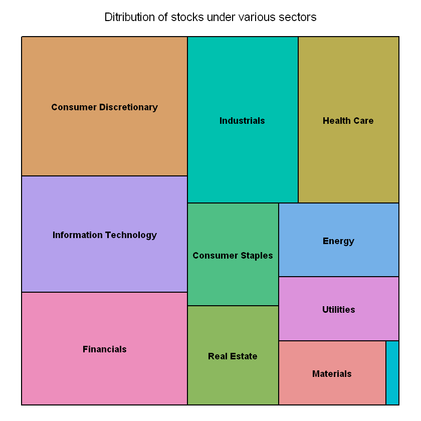

```r
treemap(df_sector,index = c("sector"),vSize ="count" ,title="Ditribution of stocks under various sectors")
```

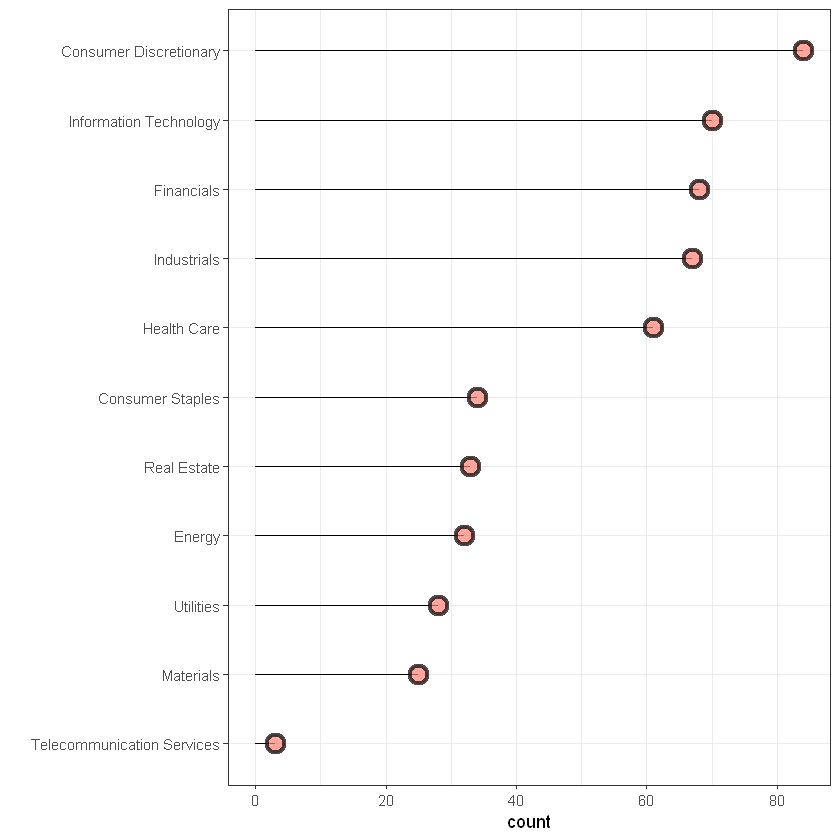

```r
#Similar represntation in a different kind of plot
plot <- df_sector %>%
  arrange(count) %>%
  mutate(sector = factor(sector, levels = sector)) %>%
  ggplot(aes(x = sector, y = count)) +
  geom_segment(aes(xend = sector, yend = 0)) +
  geom_point(size = 4, color = "black", fill = alpha("salmon", 0.4), alpha = 0.7, shape = 21, stroke = 2) +
  coord_flip() +
  xlab("") +
  theme_bw()

plot
```

#### Treemap with Category(sector) and Subcategory(stocks name) as a hierarchy.

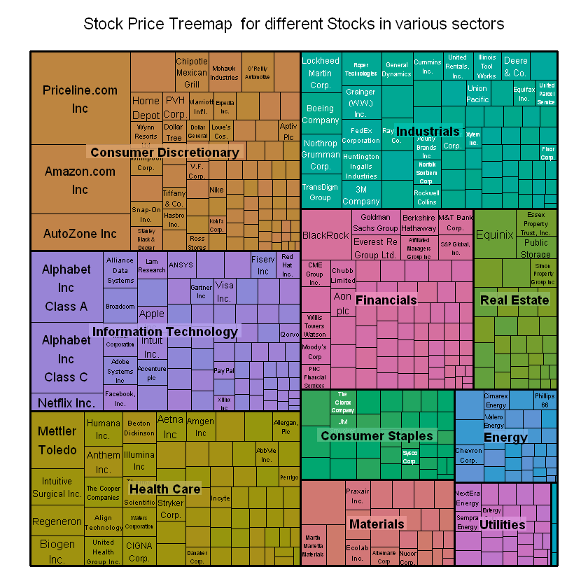

```r
treemap(stocks,index = c("sector","name"),vSize = "price",title = "Stock Price Treemap  for different Stocks in various sectors")
```

#### Treemap depicting stocks prices by size and Market capitalization by colour density - Across all sectors

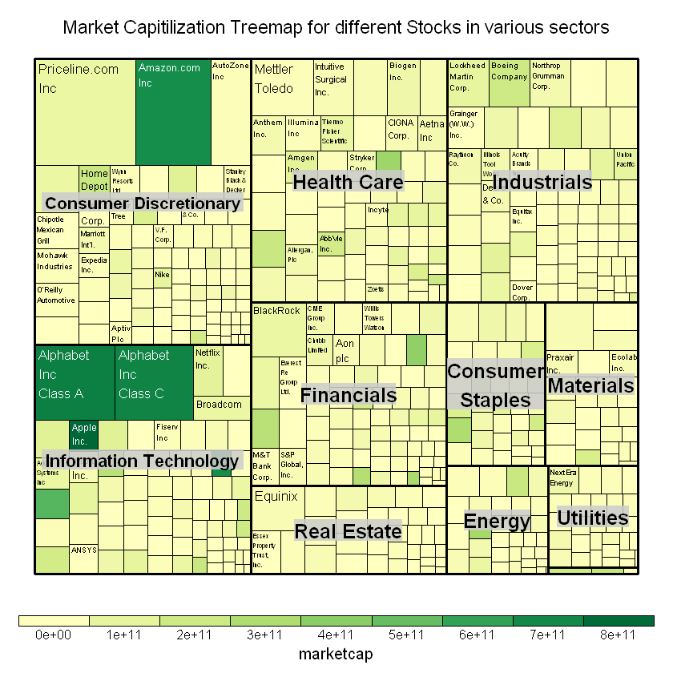

```r
treemap(stocks,index = c("sector","name"),vSize = "price",vColor = "marketcap",type="value",title = "Market Capitilization Treemap for different Stocks in various sectors",fontsize.labels = c(15,10),align.labels = list(c("centre","centre"),c("left","top")))
```

#### Barplot of the sectors with the highest price

```r
# Order stock prices from lowest to highest
df.price <- df_sector[order(df_sector$avg.price),]
df.price
```

A tibble: 11 × 9

| sector <fct> | count <int> | avg.price <int> | med.pe <dbl> | avg.eps <dbl> | cap <dbl> | ebitda <dbl> | ps <dbl> | pb <dbl> |
| --- | --- | --- | --- | --- | --- | --- | --- | --- |
| Telecommunication Services | 3 | 33 | 12.140 | 4.426667 | 208092000000 | 45745000000 | 1.511056 | 1.800 |
| Utilities | 28 | 55 | 17.960 | 2.014643 | 18458965305 | 2895500000 | 2.561081 | 1.910 |
| Energy | 32 | 57 | 25.720 | -1.648438 | 22005177414 | 2407000000 | 3.689595 | 2.190 |
| Consumer Staples | 34 | 79 | 20.485 | 3.659412 | 30771781924 | 3011012500 | 2.869688 | 6.280 |
| Real Estate | 33 | 88 | 16.550 | 2.391212 | 14394715334 | 1260662000 | 9.962681 | 2.320 |
| Financials | 68 | 89 | 16.300 | 4.436912 | 26622202518 | 0 | 3.358182 | 1.600 |
| Materials | 25 | 102 | 23.260 | 4.932000 | 16964162228 | 2152000000 | 2.876093 | 3.660 |
| Industrials | 67 | 116 | 21.600 | 5.344030 | 19363059152 | 1635916000 | 2.573401 | 4.460 |
| Information Technology | 70 | 119 | 25.165 | 3.110000 | 26937142559 | 1667542000 | 5.880142 | 5.845 |
| Consumer Discretionary | 84 | 124 | 18.770 | 4.879048 | 14342772687 | 1962093500 | 2.275769 | 3.970 |
| Health Care | 61 | 132 | 19.925 | 4.340492 | 32295200000 | 1676204000 | 4.827239 | 3.850 |

[figure not shown]

```r
# Creating the bar plot

ggplot(data = df.price, aes(x = sector, y = avg.price)) +
  geom_bar(stat="identity", fill = "#ff6666", color = "black") +
  scale_x_discrete(labels=c("Telecom", "Utilities", "Energy", "Staples", "RE",
                            "Financials", "Materials", "Industrials", "IT",
                            "Cons. Disc", "Healthcare")) +
  theme_minimal() +theme(axis.text.x = element_text(angle=55, vjust=0.5))
```

#### Barplot of highest market capitalization

```r
df.cap <- df_sector[order(df_sector$cap),]
df.cap$sector <- factor(df.cap$sector, levels = df.cap$sector)
df.cap
```

A tibble: 11 × 9

| sector <fct> | count <int> | avg.price <int> | med.pe <dbl> | avg.eps <dbl> | cap <dbl> | ebitda <dbl> | ps <dbl> | pb <dbl> |
| --- | --- | --- | --- | --- | --- | --- | --- | --- |
| Consumer Discretionary | 84 | 124 | 18.770 | 4.879048 | 14342772687 | 1962093500 | 2.275769 | 3.970 |
| Real Estate | 33 | 88 | 16.550 | 2.391212 | 14394715334 | 1260662000 | 9.962681 | 2.320 |
| Materials | 25 | 102 | 23.260 | 4.932000 | 16964162228 | 2152000000 | 2.876093 | 3.660 |
| Utilities | 28 | 55 | 17.960 | 2.014643 | 18458965305 | 2895500000 | 2.561081 | 1.910 |
| Industrials | 67 | 116 | 21.600 | 5.344030 | 19363059152 | 1635916000 | 2.573401 | 4.460 |
| Energy | 32 | 57 | 25.720 | -1.648438 | 22005177414 | 2407000000 | 3.689595 | 2.190 |
| Financials | 68 | 89 | 16.300 | 4.436912 | 26622202518 | 0 | 3.358182 | 1.600 |
| Information Technology | 70 | 119 | 25.165 | 3.110000 | 26937142559 | 1667542000 | 5.880142 | 5.845 |
| Consumer Staples | 34 | 79 | 20.485 | 3.659412 | 30771781924 | 3011012500 | 2.869688 | 6.280 |
| Health Care | 61 | 132 | 19.925 | 4.340492 | 32295200000 | 1676204000 | 4.827239 | 3.850 |
| Telecommunication Services | 3 | 33 | 12.140 | 4.426667 | 208092000000 | 45745000000 | 1.511056 | 1.800 |

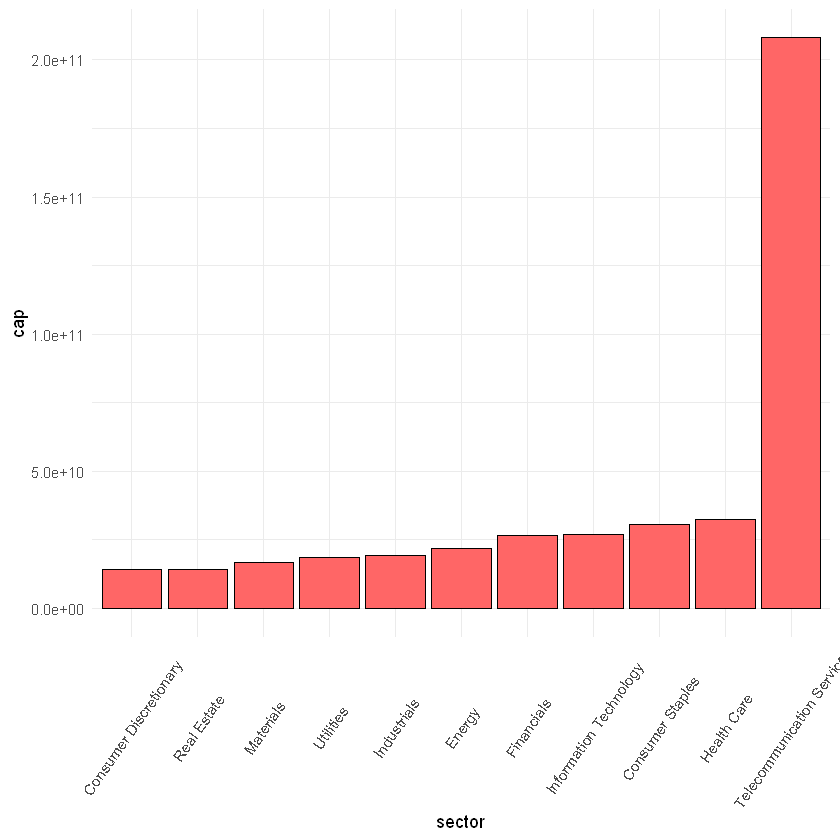

```r
ggplot(data = df.cap, aes(x = sector, y = cap)) +
  geom_bar(stat="identity", fill = "#ff6666", color = "black") +
  theme_minimal() +
  theme(axis.text.x = element_text(angle=55, vjust=0.5))
```

A tibble: 10 × 9

| sector <fct> | count <int> | avg.price <int> | med.pe <dbl> | avg.eps <dbl> | cap <dbl> | ebitda <dbl> | ps <dbl> | pb <dbl> |
| --- | --- | --- | --- | --- | --- | --- | --- | --- |
| Consumer Discretionary | 84 | 124 | 18.770 | 4.879048 | 14342772687 | 1962093500 | 2.275769 | 3.970 |
| Real Estate | 33 | 88 | 16.550 | 2.391212 | 14394715334 | 1260662000 | 9.962681 | 2.320 |
| Materials | 25 | 102 | 23.260 | 4.932000 | 16964162228 | 2152000000 | 2.876093 | 3.660 |
| Utilities | 28 | 55 | 17.960 | 2.014643 | 18458965305 | 2895500000 | 2.561081 | 1.910 |
| Industrials | 67 | 116 | 21.600 | 5.344030 | 19363059152 | 1635916000 | 2.573401 | 4.460 |
| Energy | 32 | 57 | 25.720 | -1.648438 | 22005177414 | 2407000000 | 3.689595 | 2.190 |
| Financials | 68 | 89 | 16.300 | 4.436912 | 26622202518 | 0 | 3.358182 | 1.600 |
| Information Technology | 70 | 119 | 25.165 | 3.110000 | 26937142559 | 1667542000 | 5.880142 | 5.845 |
| Consumer Staples | 34 | 79 | 20.485 | 3.659412 | 30771781924 | 3011012500 | 2.869688 | 6.280 |
| Health Care | 61 | 132 | 19.925 | 4.340492 | 32295200000 | 1676204000 | 4.827239 | 3.850 |

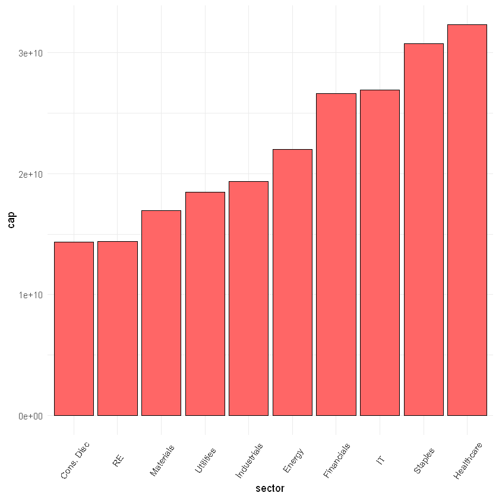

```r
#telecom companies are skewing the data in its favor
# We will keep aside the telecom sector to get a better comparitive visualisation.

df.cap.new <- subset(df.cap, sector != "Telecommunication Services")
df.cap.new


ggplot(data = df.cap.new, aes(x = sector, y = cap)) +
  geom_bar(stat="identity", fill = "#ff6666", color = "black") +
  scale_x_discrete(labels=c("Cons. Disc", "RE", "Materials",
                            "Utilities", "Industrials","Energy",
                            "Financials","IT", "Staples", "Healthcare")) +
  theme_minimal() +
  theme(axis.text.x = element_text(angle=55, vjust=0.5))
```

## 5 . Correlation Analysis and Graphs

```r
# we will start creating corr plot
# since pe and pb we will remove from our dataset
colnames(stocks)
head(stocks)
```

1. 'symbol'

2. 'name'

3. 'sector'

4. 'price'

5. 'pe'

6. 'divyield'

7. 'eps'

8. 'high'

9. 'low'

10. 'marketcap'

11. 'ebitda'

12. 'ps'

13. 'pb'

A data.frame: 6 × 13

|  | symbol <fct> | name <fct> | sector <fct> | price <dbl> | pe <dbl> | divyield <dbl> | eps <dbl> | high <dbl> | low <dbl> | marketcap <dbl> | ebitda <dbl> | ps <dbl> | pb <dbl> |
| --- | --- | --- | --- | --- | --- | --- | --- | --- | --- | --- | --- | --- | --- |
| 1 | MMM | 3M Company | Industrials | 222.89 | 24.31 | 2.3328617 | 7.92 | 259.770 | 175.490 | 138721000000 | 9048000000 | 4.390271 | 11.34 |
| 2 | AOS | A.O. Smith Corp | Industrials | 60.24 | 27.76 | 1.1479592 | 1.70 | 68.390 | 48.925 | 10783419933 | 601000000 | 3.575483 | 6.35 |
| 3 | ABT | Abbott Laboratories | Health Care | 56.27 | 22.51 | 1.9089824 | 0.26 | 64.600 | 42.280 | 102121000000 | 5744000000 | 3.740480 | 3.19 |
| 4 | ABBV | AbbVie Inc. | Health Care | 108.48 | 19.41 | 2.4995599 | 3.29 | 125.860 | 60.050 | 181386000000 | 10310000000 | 6.291571 | 26.14 |
| 5 | ACN | Accenture plc | Information Technology | 150.51 | 25.47 | 1.7144699 | 5.44 | 162.600 | 114.820 | 98765855553 | 5643228000 | 2.604117 | 10.62 |
| 6 | ATVI | Activision Blizzard | Information Technology | 65.83 | 31.80 | 0.4319032 | 1.28 | 74.945 | 38.930 | 52518668144 | 2704000000 | 10.595120 | 5.16 |

There are few empty values in pe and pb. These columns are derived columns and do not have much influence.  
These columns will be removed from the dataset as they serve no true purpose.

```r
stocks <- select(stocks , c(1,2,3,4,6,7,8,9,10,11,12))
colnames(stocks)
head(stocks)
```

1. 'symbol'

2. 'name'

3. 'sector'

4. 'price'

5. 'divyield'

6. 'eps'

7. 'high'

8. 'low'

9. 'marketcap'

10. 'ebitda'

11. 'ps'

A data.frame: 6 × 11

|  | symbol <fct> | name <fct> | sector <fct> | price <dbl> | divyield <dbl> | eps <dbl> | high <dbl> | low <dbl> | marketcap <dbl> | ebitda <dbl> | ps <dbl> |
| --- | --- | --- | --- | --- | --- | --- | --- | --- | --- | --- | --- |
| 1 | MMM | 3M Company | Industrials | 222.89 | 2.3328617 | 7.92 | 259.770 | 175.490 | 138721000000 | 9048000000 | 4.390271 |
| 2 | AOS | A.O. Smith Corp | Industrials | 60.24 | 1.1479592 | 1.70 | 68.390 | 48.925 | 10783419933 | 601000000 | 3.575483 |
| 3 | ABT | Abbott Laboratories | Health Care | 56.27 | 1.9089824 | 0.26 | 64.600 | 42.280 | 102121000000 | 5744000000 | 3.740480 |
| 4 | ABBV | AbbVie Inc. | Health Care | 108.48 | 2.4995599 | 3.29 | 125.860 | 60.050 | 181386000000 | 10310000000 | 6.291571 |
| 5 | ACN | Accenture plc | Information Technology | 150.51 | 1.7144699 | 5.44 | 162.600 | 114.820 | 98765855553 | 5643228000 | 2.604117 |
| 6 | ATVI | Activision Blizzard | Information Technology | 65.83 | 0.4319032 | 1.28 | 74.945 | 38.930 | 52518668144 | 2704000000 | 10.595120 |

```r
#         Correlation analysis         #

corr  <- cor(stocks %>%  select(price,divyield,eps,low,high,marketcap,ebitda))
corr
```

A matrix: 7 × 7 of type dbl

|  | price | divyield | eps | low | high | marketcap | ebitda |
| --- | --- | --- | --- | --- | --- | --- | --- |
| price | 1.0000000 | -0.24462965 | 0.59106119 | 0.9827875 | 0.9950764 | 0.40647417 | 0.1803206 |
| divyield | -0.2446296 | 1.00000000 | -0.07723511 | -0.2079531 | -0.2444259 | -0.02179357 | 0.1261334 |
| eps | 0.5910612 | -0.07723511 | 1.00000000 | 0.6048940 | 0.5885947 | 0.19406267 | 0.1805832 |
| low | 0.9827875 | -0.20795311 | 0.60489398 | 1.0000000 | 0.9848528 | 0.37558814 | 0.1796658 |
| high | 0.9950764 | -0.24442592 | 0.58859470 | 0.9848528 | 1.0000000 | 0.39850371 | 0.1762775 |
| marketcap | 0.4064742 | -0.02179357 | 0.19406267 | 0.3755881 | 0.3985037 | 1.00000000 | 0.7713442 |
| ebitda | 0.1803206 | 0.12613344 | 0.18058322 | 0.1796658 | 0.1762775 | 0.77134419 | 1.0000000 |

Finding the spread of values for each variable

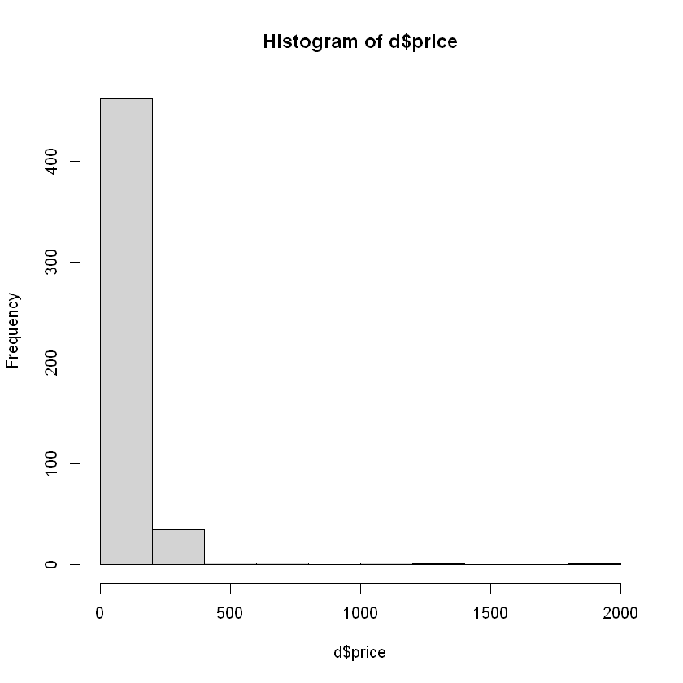

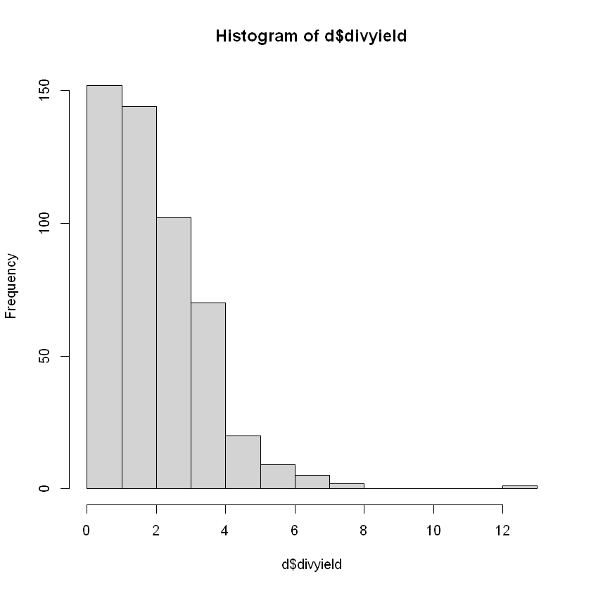

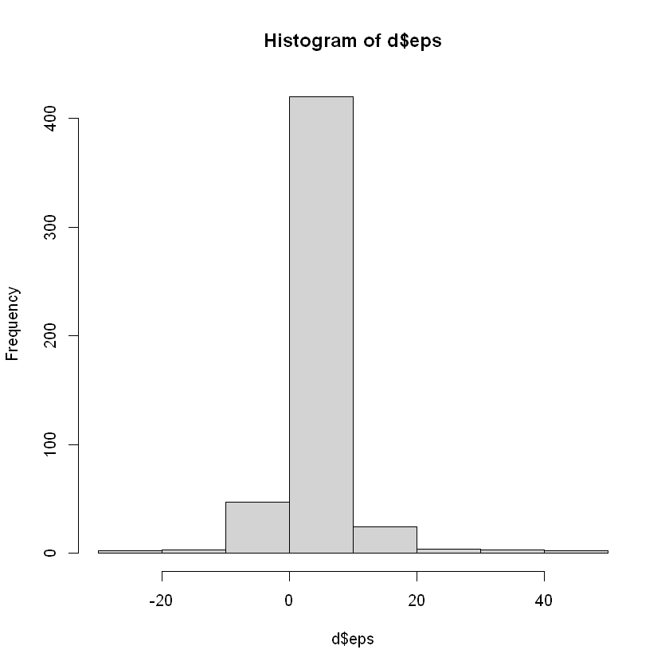

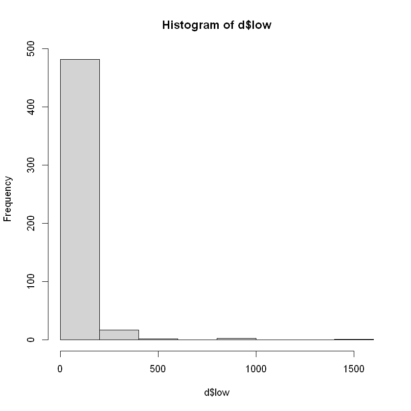

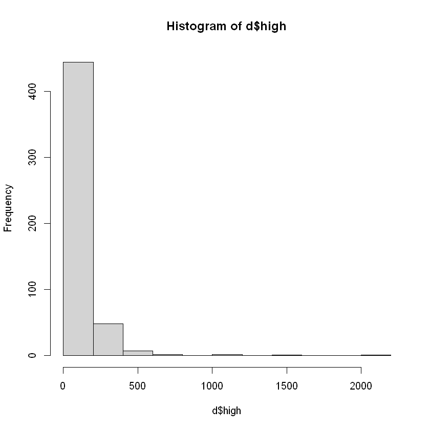

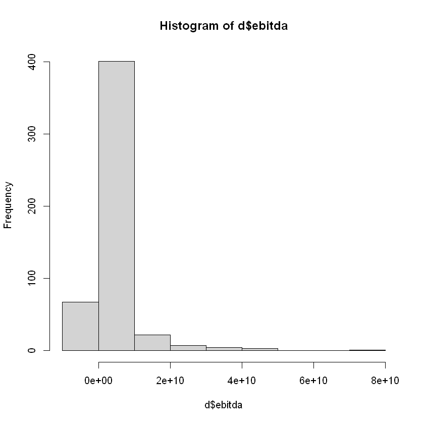

```r
d <- stocks
hist(d$price)
hist(d$divyield)
hist(d$eps)
hist(d$low)
hist(d$high)
hist(d$ebitda)
```

### Correlation Matrix

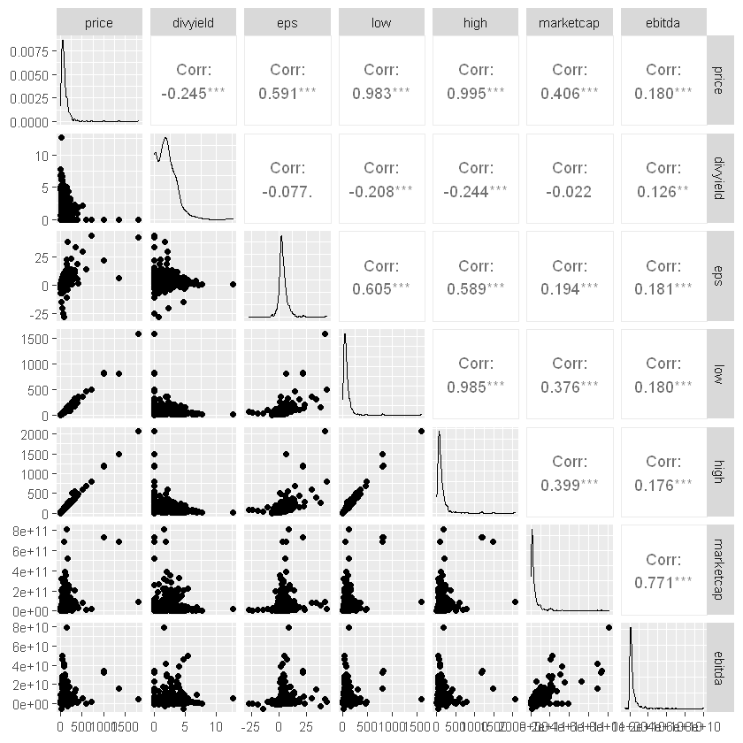

[figure not shown]

```r
ggpairs(d %>% select(price,divyield,eps,low,high,marketcap,ebitda))

d %>% select(price,divyield,eps,low,high,marketcap,ebitda) %>%
  corrgram()
```

Observations: The correlation between each of variables is shown on the correlation matrix.  
To summarize we observe,

- A small negative linear association between dividend yield and price (rho estimate=-0.245)
- A moderately strong linear association between earnings per share and price (rho estimate=0.591)
- A relatively strong linear relationship between market cap and EBITDA with a rho estimate of 0.771
- A very strong linear association between high and price with a rho estimate of 0.995 and also a strong linear association between low and price with a rho estimate of 0.983

## 6 . Analysis using various models

We have decided that the response variable is **Earnings/Share (eps).**  
Dividend yield(divyield), Market Capitalization(marketcap), Earnings before interest, taxes, depreciation, and amortization(ebitda) , Stock Price(price) are the chosen predictor variables.  
The 52 week high and low are not chosen as predictor variables as they are only maximum and minimum values of stock price in a year.

### Linear Regression

We will perform linear regression in R using the stocks dataset and fitting a simple linear regression that models eps as a function of divyield.  
The mathematical model is: eps = α + β divyield + ϵ

```r
model1 <- lm(eps ~ divyield, d)
summary(model1)
```

```
Call:
lm(formula = eps ~ divyield, data = d)

Residuals:
    Min      1Q  Median      3Q     Max
-32.097  -2.198  -0.841   1.422  39.794

Coefficients:
            Estimate Std. Error t value Pr(>|t|)
(Intercept)   4.2957     0.4014  10.701   <2e-16 ***
divyield     -0.2858     0.1645  -1.737   0.0829 .
---
Signif. codes:  0 '***' 0.001 '**' 0.01 '*' 0.05 '.' 0.1 ' ' 1

Residual standard error: 5.678 on 503 degrees of freedom
Multiple R-squared:  0.005965,	Adjusted R-squared:  0.003989
F-statistic: 3.019 on 1 and 503 DF,  p-value: 0.08293
```

Observation:

We can see that divyieldis negatively correlated to eps.  
But it is not statistically significant.

### Regression Diagnostics

We will check if the four assumptions of linear regression for this model are met:

- The error terms are independent of each other (i.e. the error term of one observation is independent of another observation)
- The errors are normally distributed
- The errors are distributed with a mean of zero
- The errors are distributed with a constant variance (i.e. the assumption of homoscedasticity)

#### Assumption of Normality

We will plot a histogram for the residuals and perform Shapiro-Wilk Normality Test.

```
	Shapiro-Wilk normality test

data:  model1$residuals
W = 0.7392, p-value < 2.2e-16
```

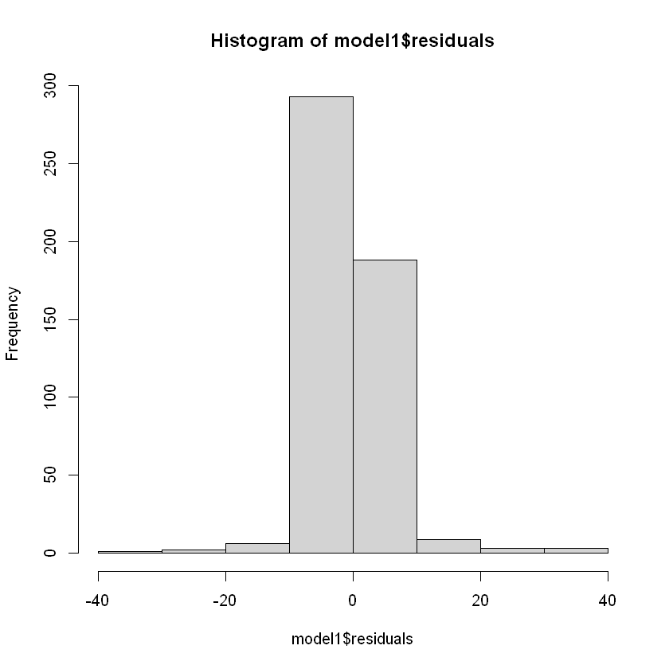

```r
hist(model1$residuals)
shapiro.test(model1$residuals)
```

By visual inspection residuals seem to be normally distributed.  
The Shapiro-Wilk Normality Test gives the p value < 0.05  
This says that, we can reject the null hypothesis that the residuals are normally distributed.

Let us perform the remaining tests..

#### Assumption of a Zero Mean

We can use the t.test function to test if the mean of a variable is statistically significantly different than zero.

```r
t.test(model1$residuals)
```

```
	One Sample t-test

data:  model1$residuals
t = 1.0415e-15, df = 504, p-value = 1
alternative hypothesis: true mean is not equal to 0
95 percent confidence interval:
 -0.4958908  0.4958908
sample estimates:
   mean of x
2.628742e-16
```

#### Assumption of Constant Variance

We will plot()the residuals versus the predicted eps values.

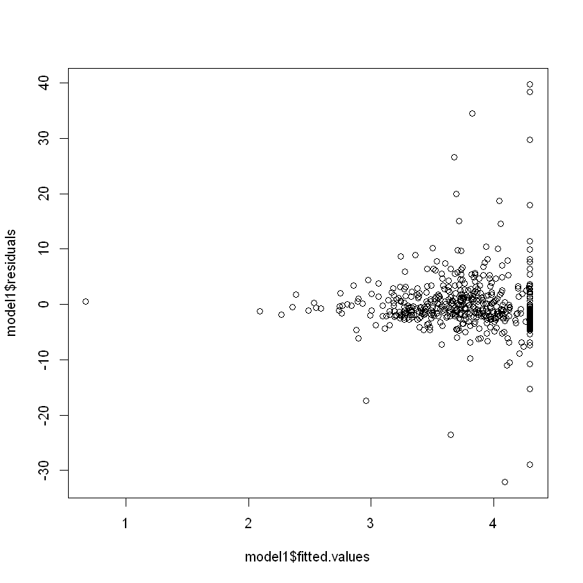

```r
plot(model1$fitted.values, model1$residuals)
```

We will recheck the scatter plot of divyield vs eps since the model1 seems completely inappropriate.

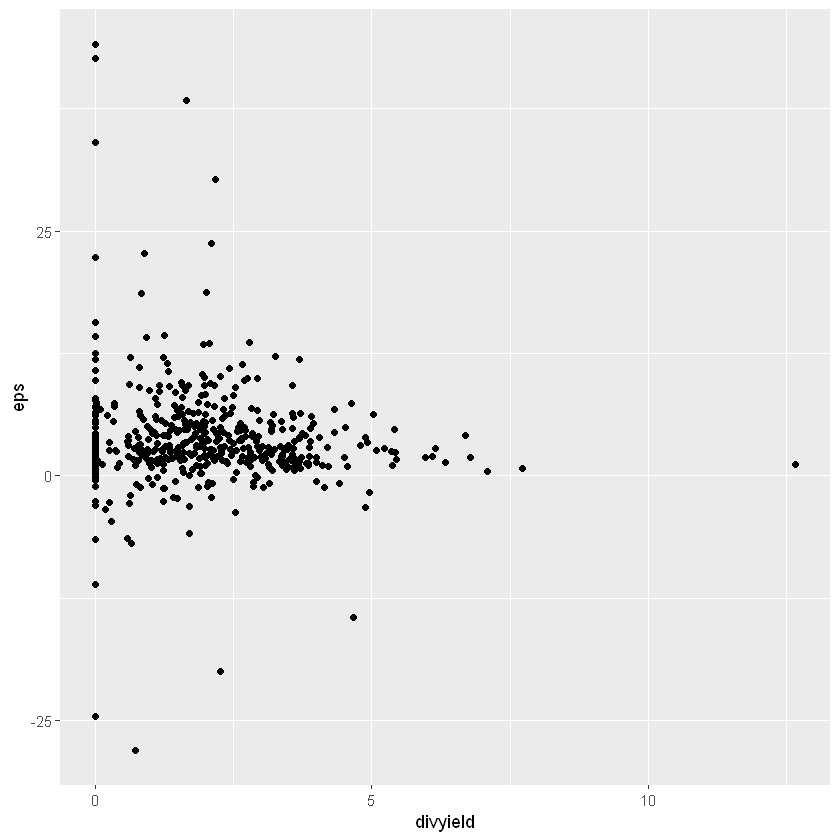

```r
ggplot(d) + geom_point(aes(x=divyield, y=eps))
```

From this graph, it’s clear that the relationship between eps and divyield exhibits a high degree of non-linearity.  
With this in mind, we will try other models(using different predictor variables) in order to use linear regression.

```
Call:
lm(formula = eps ~ marketcap, data = d)

Residuals:
    Min      1Q  Median      3Q     Max
-31.311  -2.197  -0.685   1.374  40.696

Coefficients:
             Estimate Std. Error t value Pr(>|t|)
(Intercept) 3.150e+00  2.834e-01  11.115  < 2e-16 ***
marketcap   1.226e-11  2.763e-12   4.437 1.12e-05 ***
---
Signif. codes:  0 '***' 0.001 '**' 0.01 '*' 0.05 '.' 0.1 ' ' 1

Residual standard error: 5.586 on 503 degrees of freedom
Multiple R-squared:  0.03766,	Adjusted R-squared:  0.03575
F-statistic: 19.68 on 1 and 503 DF,  p-value: 1.123e-05
```

```
	One Sample t-test

data:  model2$residuals
t = 1.104e-15, df = 504, p-value = 1
alternative hypothesis: true mean is not equal to 0
95 percent confidence interval:
 -0.4879209  0.4879209
sample estimates:
   mean of x
2.741726e-16
```

```
	Shapiro-Wilk normality test

data:  model2$residuals
W = 0.73791, p-value < 2.2e-16
```

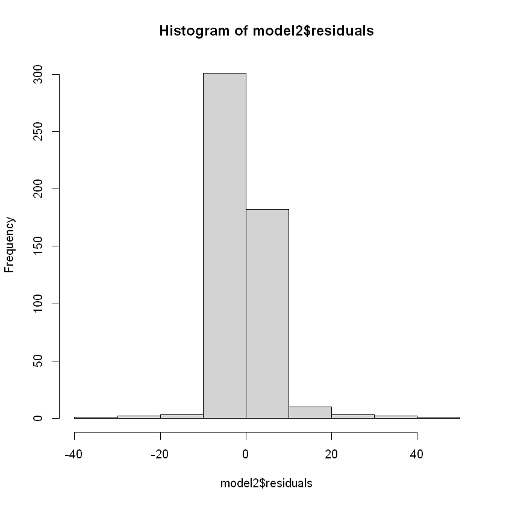

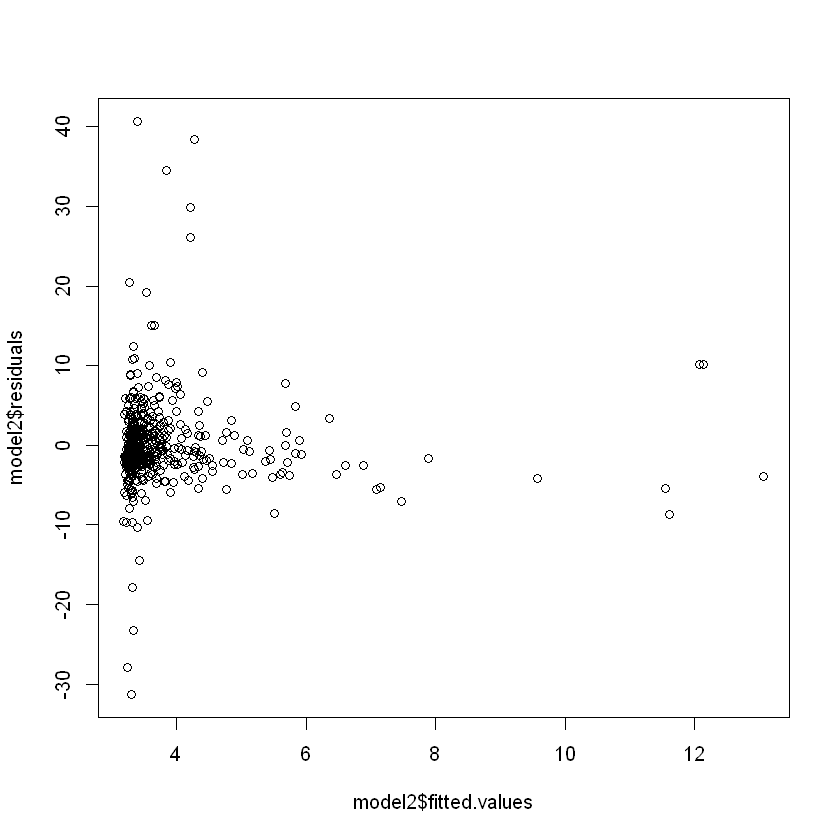

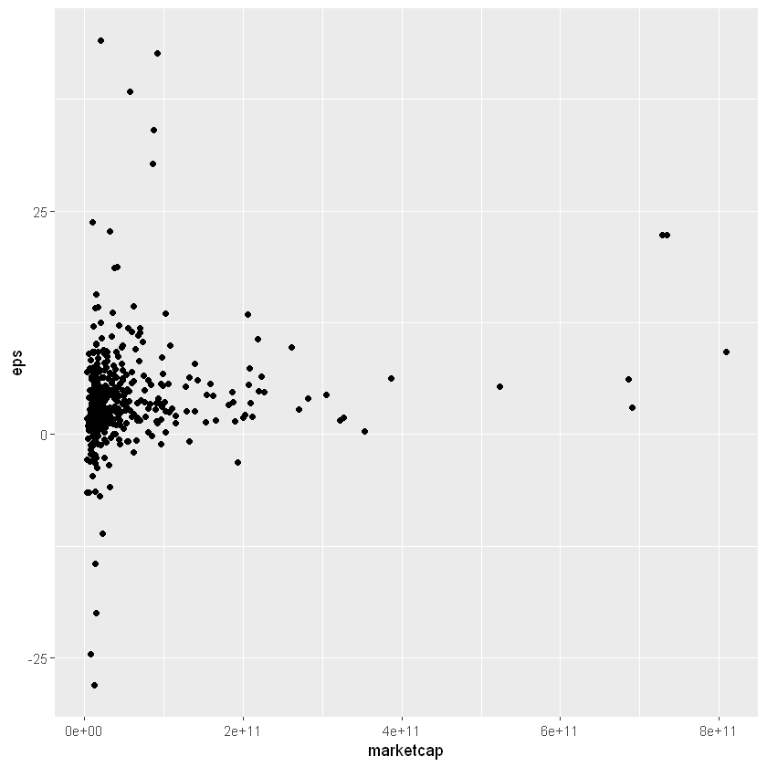

```r
model2 <- lm(eps ~ marketcap ,d )
summary(model2)

hist(model2$residuals)
t.test(model2$residuals)
shapiro.test(model2$residuals)
plot(model2$fitted.values, model2$residuals)
ggplot(d) + geom_point(aes(x=marketcap, y=eps))
```

```
Call:
lm(formula = eps ~ ebitda, data = d)

Residuals:
    Min      1Q  Median      3Q     Max
-31.225  -2.215  -0.722   1.242  40.523

Coefficients:
             Estimate Std. Error t value Pr(>|t|)
(Intercept) 3.215e+00  2.815e-01  11.417  < 2e-16 ***
ebitda      1.502e-10  3.647e-11   4.118 4.47e-05 ***
---
Signif. codes:  0 '***' 0.001 '**' 0.01 '*' 0.05 '.' 0.1 ' ' 1

Residual standard error: 5.601 on 503 degrees of freedom
Multiple R-squared:  0.03261,	Adjusted R-squared:  0.03069
F-statistic: 16.96 on 1 and 503 DF,  p-value: 4.472e-05
```

```
	Shapiro-Wilk normality test

data:  model3$residuals
W = 0.7345, p-value < 2.2e-16
```

```
	One Sample t-test

data:  model3$residuals
t = -7.7229e-16, df = 504, p-value = 1
alternative hypothesis: true mean is not equal to 0
95 percent confidence interval:
 -0.4891995  0.4891995
sample estimates:
    mean of x
-1.922988e-16
```

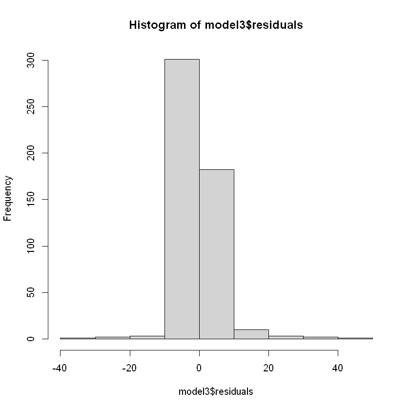

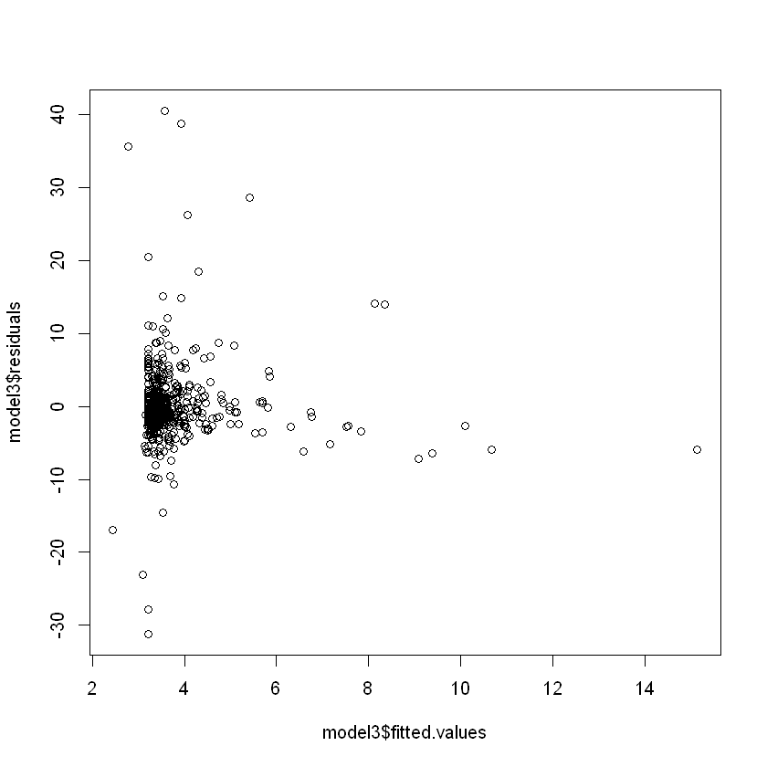

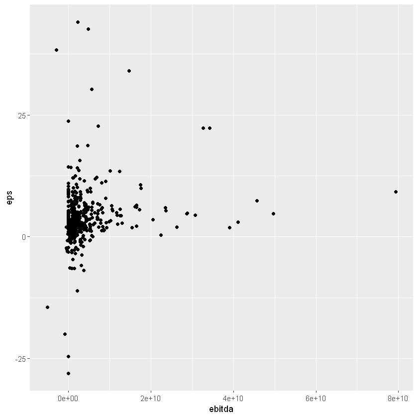

```r
model3 <- lm(eps ~ebitda, d)
summary(model3)
shapiro.test(model3$residuals)
hist(model3$residuals)
t.test(model3$residuals)
plot(model3$fitted.values, model3$residuals)
ggplot(d) + geom_point(aes(x=ebitda, y=eps))
```

```
Call:
lm(formula = eps ~ price, data = d)

Residuals:
    Min      1Q  Median      3Q     Max
-31.279  -1.273  -0.189   1.328  33.086

Coefficients:
            Estimate Std. Error t value Pr(>|t|)
(Intercept) 1.156527   0.258377   4.476 9.41e-06 ***
price       0.025014   0.001522  16.434  < 2e-16 ***
---
Signif. codes:  0 '***' 0.001 '**' 0.01 '*' 0.05 '.' 0.1 ' ' 1

Residual standard error: 4.593 on 503 degrees of freedom
Multiple R-squared:  0.3494,	Adjusted R-squared:  0.3481
F-statistic: 270.1 on 1 and 503 DF,  p-value: < 2.2e-16
```

```
	Shapiro-Wilk normality test

data:  model4$residuals
W = 0.72382, p-value < 2.2e-16
```

```
	One Sample t-test

data:  model4$residuals
t = 4.6304e-16, df = 504, p-value = 1
alternative hypothesis: true mean is not equal to 0
95 percent confidence interval:
 -0.4011972  0.4011972
sample estimates:
   mean of x
9.455402e-17
```

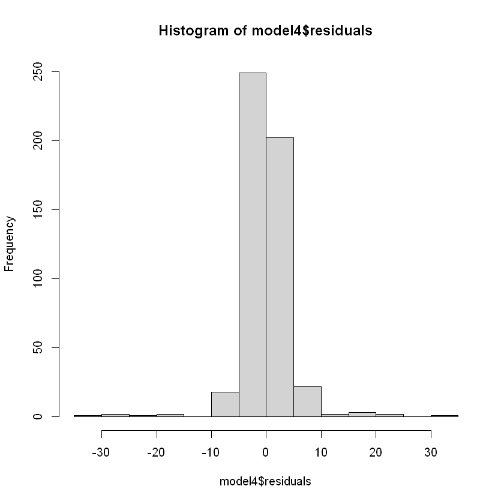

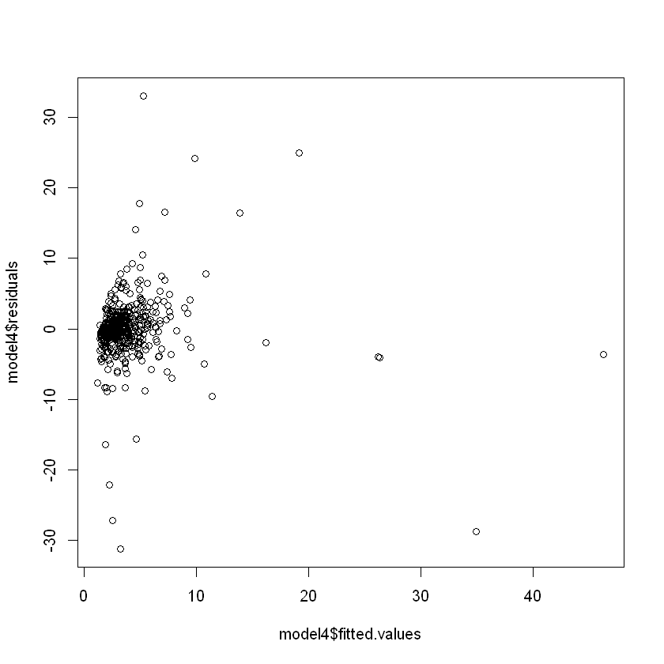

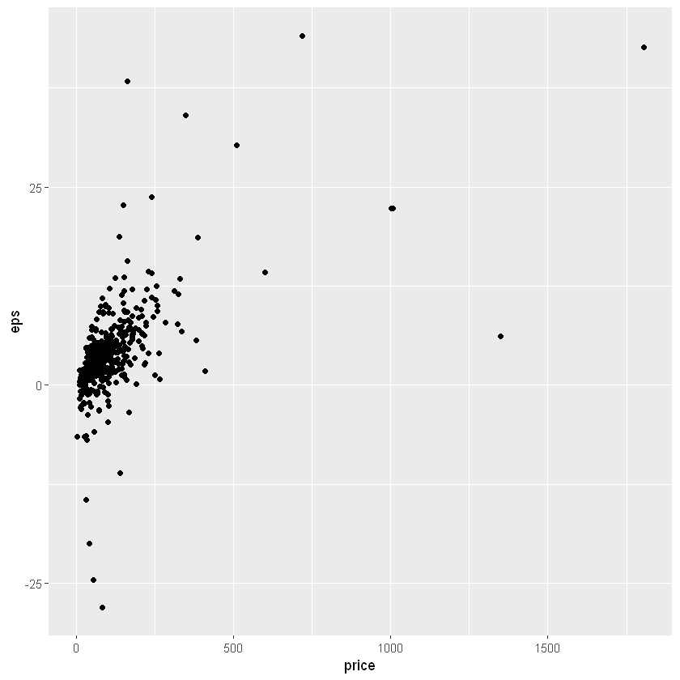

```r
model4 <- lm(eps ~ price, d)
summary(model4)
shapiro.test(model4$residuals)
hist(model4$residuals)
t.test(model4$residuals)
plot(model4$fitted.values, model4$residuals)
ggplot(d) + geom_point(aes(x=price, y=eps))
```

Observation: From this graph, it’s clear that the relationship between eps and price exhibits a low degree of non-linearity.  
We can clearly see that the residuals, and the variance of the residuals certainly doesn’t appear constant across all levels of the fitted values for eps.

### Multiple Regressions

Ordinary inear squares (OLS) regression compares the response of a dependent variable given a change in some explanatory variables. However, a dependent variable is rarely explained by only one variable. In this case,we can use multiple regression, which attempts to explain a dependent variable using more than one independent variable. Multiple regressions can be linear and nonlinear.

**Multiple regressions** are based on the assumption that there is a linear relationship between both the dependent and independent variables. It also assumes no major correlation between the independent variables.

The way to do multiple regression in R is,  
lm (response_variable ~ predictor_variable1 + predictor_variable2 +..., data = data)

```
Call:
lm(formula = eps ~ ebitda + marketcap + price + divyield, data = d)

Residuals:
    Min      1Q  Median      3Q     Max
-30.866  -1.248  -0.136   1.122  34.577

Coefficients:
              Estimate Std. Error t value Pr(>|t|)
(Intercept)  5.654e-01  3.866e-01   1.463    0.144
ebitda       2.338e-10  4.776e-11   4.895 1.33e-06 ***
marketcap   -1.861e-11  3.858e-12  -4.824 1.87e-06 ***
price        2.840e-02  1.707e-03  16.635  < 2e-16 ***
divyield     1.668e-01  1.363e-01   1.224    0.222
---
Signif. codes:  0 '***' 0.001 '**' 0.01 '*' 0.05 '.' 0.1 ' ' 1

Residual standard error: 4.473 on 500 degrees of freedom
Multiple R-squared:  0.3868,	Adjusted R-squared:  0.3819
F-statistic: 78.85 on 4 and 500 DF,  p-value: < 2.2e-16
```

```
	One Sample t-test

data:  model5$residuals
t = -1.8594e-16, df = 504, p-value = 1
alternative hypothesis: true mean is not equal to 0
95 percent confidence interval:
 -0.3894818  0.3894818
sample estimates:
    mean of x
-3.686116e-17
```

```
	Shapiro-Wilk normality test

data:  model5$residuals
W = 0.73123, p-value < 2.2e-16
```

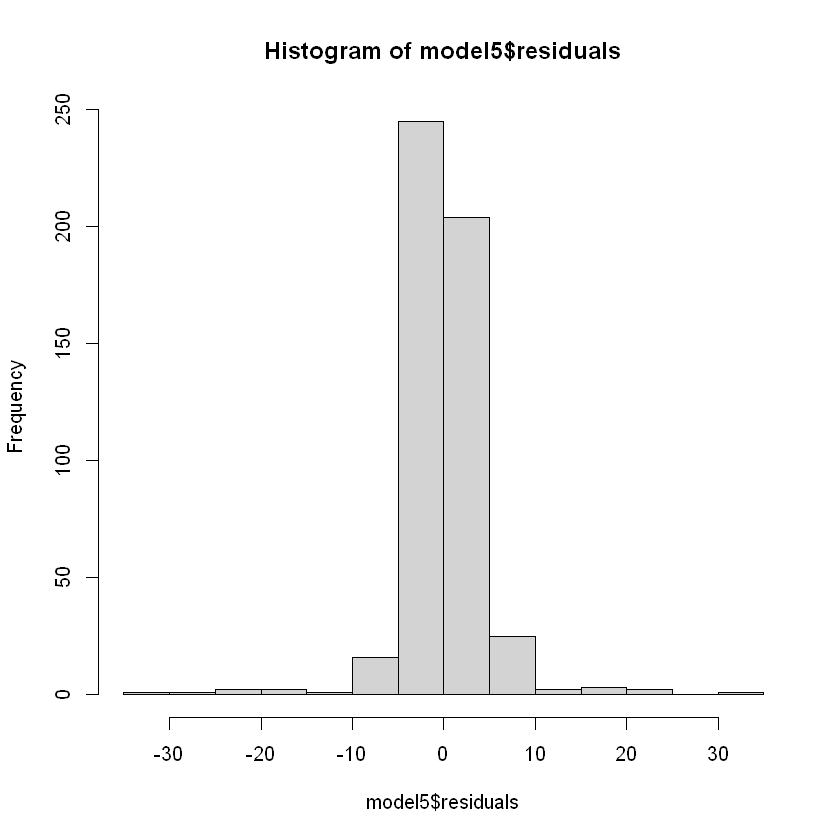

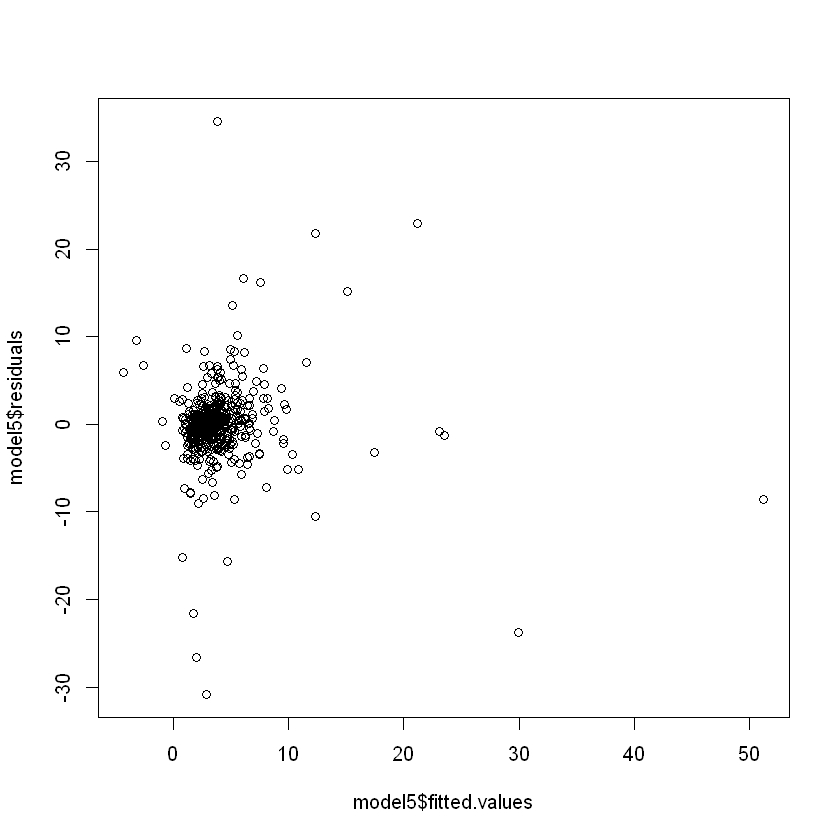

```r
model5 <- lm(eps ~ ebitda+ marketcap + price+  divyield, d)
summary(model5)

hist(model5$residuals)
t.test(model5$residuals)
shapiro.test(model5$residuals)
plot(model5$fitted.values, model5$residuals)
```

Observation: From this graph, it’s clear that the relationship between eps and (ebitda+ marketcap + price+ divyield) exhibits less degree of non-linearity. This multiple linear regression is non-linear.

Looking at model 5 we can try to make an appropriate set of transformations to the variables in the model to arrive at a linear relationship between the transformed variables in order to use linear regression. This is the custom model (model6)

```
Call:
lm(formula = eps ~ log(price) + ebitda + log(marketcap) + divyield,
    data = d)

Residuals:
    Min      1Q  Median      3Q     Max
-31.833  -1.496   0.019   1.561  32.149

Coefficients:
                 Estimate Std. Error t value Pr(>|t|)
(Intercept)    -7.088e+00  6.354e+00  -1.116  0.26513
log(price)      4.442e+00  3.058e-01  14.528  < 2e-16 ***
ebitda          1.064e-10  3.935e-11   2.704  0.00709 **
log(marketcap) -3.898e-01  2.848e-01  -1.369  0.17173
divyield        3.568e-01  1.432e-01   2.491  0.01307 *
---
Signif. codes:  0 '***' 0.001 '**' 0.01 '*' 0.05 '.' 0.1 ' ' 1

Residual standard error: 4.617 on 500 degrees of freedom
Multiple R-squared:  0.3465,	Adjusted R-squared:  0.3412
F-statistic: 66.26 on 4 and 500 DF,  p-value: < 2.2e-16
```

```
	One Sample t-test

data:  model6$residuals
t = 3.9331e-16, df = 504, p-value = 1
alternative hypothesis: true mean is not equal to 0
95 percent confidence interval:
 -0.4020894  0.4020894
sample estimates:
  mean of x
8.04946e-17
```

```
	Shapiro-Wilk normality test

data:  model6$residuals
W = 0.74653, p-value < 2.2e-16
```

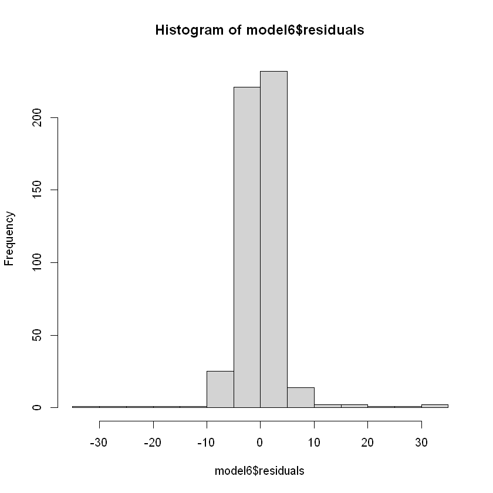

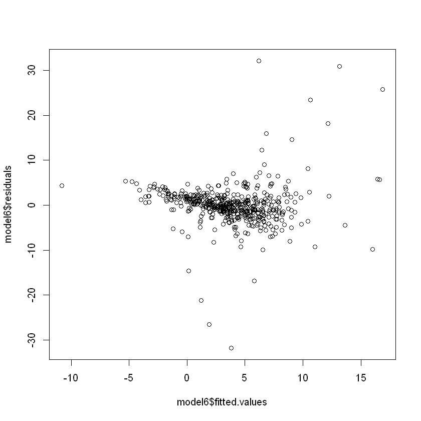

```r
model6 <- lm(eps ~ log(price) + ebitda +  log(marketcap) +  divyield, d)
summary(model6)
t.test(model6$residuals)
shapiro.test(model6$residuals)
hist(model6$residuals)
plot(model6$fitted.values, model6$residuals)
```